# Project: Investigate a Dataset - TMDb Movie Dataset

- Introduction
- Data Wrangling
- Exploratory Data Analysis
  - Q1: What variables lead to higher movie revenue?
    - 1.1: The relation between revenue and budget
      - 1.1.1: Find the movie with the highest revenue and its corresponding budget
      - 1.1.2: Find the movie with the highest budget and its corresponding revenue
    - 1.2: The relation between revenue and vote avarage
    - 1.3: The relation between revenue and popularity
    - 1.4: The count of successful and failed movies
  - Q2: How are movies distributed by genre?
    - 2.1: Which genres are most popular from year to year?
    - 2.2: Which movie genre is the most popular across all years in the dataset?
    - 2.3: Which movie genre is the most popular in the most occurring year in the dataset?
- Conclusions

## Introduction

### Dataset Description

This data set contains information about 10,000 movies collected from **The Movie Database (TMDb)**, including user ratings and revenue.

```python
# import needed packages
import pandas as pd
import numpy as np
import matplotlib.pyplot as plt
```

```python
# loading dataset using pandas
df = pd.read_csv('Database_TMDb_movie_data/tmdb-movies.csv')
```

**The Dataset contains multiple columns as shown in the list bellow:**

```python
print("Names of the Columns:", df.columns.tolist())
```

```
Names of the Columns: ['id', 'imdb_id', 'popularity', 'budget', 'revenue', 'original_title', 'cast', 'homepage', 'director', 'tagline', 'keywords', 'overview', 'runtime', 'genres', 'production_companies', 'release_date', 'vote_count', 'vote_average', 'release_year', 'budget_adj', 'revenue_adj']
```

### Questions for Analysis

1. What variables lead to higher movie revenue?
2. How are movies distributed by genre?

## Data Wrangling

**Lets look at the first few lines of the dataset**

```python
# print out lines of data
df.head()
```

|  | id | imdb_id | popularity | budget | revenue | original_title | cast | homepage | director | tagline | ... | overview | runtime | genres | production_companies | release_date | vote_count | vote_average | release_year | budget_adj | revenue_adj |
| --- | --- | --- | --- | --- | --- | --- | --- | --- | --- | --- | --- | --- | --- | --- | --- | --- | --- | --- | --- | --- | --- |
| 0 | 135397 | tt0369610 | 32.985763 | 150000000 | 1513528810 | Jurassic World | Chris Pratt\|Bryce Dallas Howard\|Irrfan Khan\|Vi... | http://www.jurassicworld.com/ | Colin Trevorrow | The park is open. | ... | Twenty-two years after the events of Jurassic ... | 124 | Action\|Adventure\|Science Fiction\|Thriller | Universal Studios\|Amblin Entertainment\|Legenda... | 6/9/15 | 5562 | 6.5 | 2015 | 1.379999e+08 | 1.392446e+09 |
| 1 | 76341 | tt1392190 | 28.419936 | 150000000 | 378436354 | Mad Max: Fury Road | Tom Hardy\|Charlize Theron\|Hugh Keays-Byrne\|Nic... | http://www.madmaxmovie.com/ | George Miller | What a Lovely Day. | ... | An apocalyptic story set in the furthest reach... | 120 | Action\|Adventure\|Science Fiction\|Thriller | Village Roadshow Pictures\|Kennedy Miller Produ... | 5/13/15 | 6185 | 7.1 | 2015 | 1.379999e+08 | 3.481613e+08 |
| 2 | 262500 | tt2908446 | 13.112507 | 110000000 | 295238201 | Insurgent | Shailene Woodley\|Theo James\|Kate Winslet\|Ansel... | http://www.thedivergentseries.movie/#insurgent | Robert Schwentke | One Choice Can Destroy You | ... | Beatrice Prior must confront her inner demons ... | 119 | Adventure\|Science Fiction\|Thriller | Summit Entertainment\|Mandeville Films\|Red Wago... | 3/18/15 | 2480 | 6.3 | 2015 | 1.012000e+08 | 2.716190e+08 |
| 3 | 140607 | tt2488496 | 11.173104 | 200000000 | 2068178225 | Star Wars: The Force Awakens | Harrison Ford\|Mark Hamill\|Carrie Fisher\|Adam D... | http://www.starwars.com/films/star-wars-episod... | J.J. Abrams | Every generation has a story. | ... | Thirty years after defeating the Galactic Empi... | 136 | Action\|Adventure\|Science Fiction\|Fantasy | Lucasfilm\|Truenorth Productions\|Bad Robot | 12/15/15 | 5292 | 7.5 | 2015 | 1.839999e+08 | 1.902723e+09 |
| 4 | 168259 | tt2820852 | 9.335014 | 190000000 | 1506249360 | Furious 7 | Vin Diesel\|Paul Walker\|Jason Statham\|Michelle ... | http://www.furious7.com/ | James Wan | Vengeance Hits Home | ... | Deckard Shaw seeks revenge against Dominic Tor... | 137 | Action\|Crime\|Thriller | Universal Pictures\|Original Film\|Media Rights ... | 4/1/15 | 2947 | 7.3 | 2015 | 1.747999e+08 | 1.385749e+09 |

5 rows × 21 columns

**To define the size of the data frame:**

```python
df.shape
```

```
(10866, 21)
```

We find out that the dataset consists of **10866** rows and **21** columns.

Now lets look at the **data types** of the columns we will be working with later:

```python
df.dtypes
```

```
id                        int64
imdb_id                  object
popularity              float64
budget                    int64
revenue                   int64
original_title           object
cast                     object
homepage                 object
director                 object
tagline                  object
keywords                 object
overview                 object
runtime                   int64
genres                   object
production_companies     object
release_date             object
vote_count                int64
vote_average            float64
release_year              int64
budget_adj              float64
revenue_adj             float64
dtype: object
```

Now we'll see **information about the DataFrame**, including the non-null values, that we will use in the cleaning data section later:

```python
df.info()
```

```
<class 'pandas.core.frame.DataFrame'>
RangeIndex: 10866 entries, 0 to 10865
Data columns (total 21 columns):
 #   Column                Non-Null Count  Dtype
---  ------                --------------  -----
 0   id                    10866 non-null  int64
 1   imdb_id               10856 non-null  object
 2   popularity            10866 non-null  float64
 3   budget                10866 non-null  int64
 4   revenue               10866 non-null  int64
 5   original_title        10866 non-null  object
 6   cast                  10790 non-null  object
 7   homepage              2936 non-null   object
 8   director              10822 non-null  object
 9   tagline               8042 non-null   object
 10  keywords              9373 non-null   object
 11  overview              10862 non-null  object
 12  runtime               10866 non-null  int64
 13  genres                10843 non-null  object
 14  production_companies  9836 non-null   object
 15  release_date          10866 non-null  object
 16  vote_count            10866 non-null  int64
 17  vote_average          10866 non-null  float64
 18  release_year          10866 non-null  int64
 19  budget_adj            10866 non-null  float64
 20  revenue_adj           10866 non-null  float64
dtypes: float64(4), int64(6), object(11)
memory usage: 1.7+ MB
```

In the cell below we will get a **statistics summary** including values like: `count`,`mean`,`standard deviation`, `quantiles`.

```python
df.describe()
```

|  | id | popularity | budget | revenue | runtime | vote_count | vote_average | release_year | budget_adj | revenue_adj |
| --- | --- | --- | --- | --- | --- | --- | --- | --- | --- | --- |
| count | 10866.000000 | 10866.000000 | 1.086600e+04 | 1.086600e+04 | 10866.000000 | 10866.000000 | 10866.000000 | 10866.000000 | 1.086600e+04 | 1.086600e+04 |
| mean | 66064.177434 | 0.646441 | 1.462570e+07 | 3.982332e+07 | 102.070863 | 217.389748 | 5.974922 | 2001.322658 | 1.755104e+07 | 5.136436e+07 |
| std | 92130.136561 | 1.000185 | 3.091321e+07 | 1.170035e+08 | 31.381405 | 575.619058 | 0.935142 | 12.812941 | 3.430616e+07 | 1.446325e+08 |
| min | 5.000000 | 0.000065 | 0.000000e+00 | 0.000000e+00 | 0.000000 | 10.000000 | 1.500000 | 1960.000000 | 0.000000e+00 | 0.000000e+00 |
| 25% | 10596.250000 | 0.207583 | 0.000000e+00 | 0.000000e+00 | 90.000000 | 17.000000 | 5.400000 | 1995.000000 | 0.000000e+00 | 0.000000e+00 |
| 50% | 20669.000000 | 0.383856 | 0.000000e+00 | 0.000000e+00 | 99.000000 | 38.000000 | 6.000000 | 2006.000000 | 0.000000e+00 | 0.000000e+00 |
| 75% | 75610.000000 | 0.713817 | 1.500000e+07 | 2.400000e+07 | 111.000000 | 145.750000 | 6.600000 | 2011.000000 | 2.085325e+07 | 3.369710e+07 |
| max | 417859.000000 | 32.985763 | 4.250000e+08 | 2.781506e+09 | 900.000000 | 9767.000000 | 9.200000 | 2015.000000 | 4.250000e+08 | 2.827124e+09 |

In the cell below shows the **number of unique values** for each column:

```python
df.nunique()
```

```
id                      10865
imdb_id                 10855
popularity              10814
budget                    557
revenue                  4702
original_title          10571
cast                    10719
homepage                 2896
director                 5067
tagline                  7997
keywords                 8804
overview                10847
runtime                   247
genres                   2039
production_companies     7445
release_date             5909
vote_count               1289
vote_average               72
release_year               56
budget_adj               2614
revenue_adj              4840
dtype: int64
```

The `.count()` function returns the number of non-null values in each column of the dataset.

```python
df.count()
```

```
id                      10866
imdb_id                 10856
popularity              10866
budget                  10866
revenue                 10866
original_title          10866
cast                    10790
homepage                 2936
director                10822
tagline                  8042
keywords                 9373
overview                10862
runtime                 10866
genres                  10843
production_companies     9836
release_date            10866
vote_count              10866
vote_average            10866
release_year            10866
budget_adj              10866
revenue_adj             10866
dtype: int64
```

### Data Cleaning

In this section we'll clean the dataset to obtain the most informative findings.

### *Fixing Null-Values*

As we see above, the dataset has many null-values that need to be fixed.

- For columns with few missing values, such as `imdb_id`,`cast`,`director`,and `genres` we will drop the rows with the missing data.

```python
df.dropna(subset=['imdb_id','cast','director','genres'], inplace=True)
```

- We'll drop unneeded columns from the dataset, like `homepage`(which is almost empty), `tagline`, `overview`.

```python
columns=['homepage','tagline','overview']
df.drop(columns, axis=1, inplace=True)
```

**Now lets see what remains null**

```python
df.isnull().sum()
```

```
id                         0
imdb_id                    0
popularity                 0
budget                     0
revenue                    0
original_title             0
cast                       0
director                   0
keywords                1423
runtime                    0
genres                     0
production_companies     956
release_date               0
vote_count                 0
vote_average               0
release_year               0
budget_adj                 0
revenue_adj                0
dtype: int64
```

- For columns like `keywords` and `production_companies` i will replace them with **Unkown** value incase i need to use them later

```python
df['keywords'].fillna("Unknown", inplace=True)
df['production_companies'].fillna("Unknown", inplace=True)
```

**Recheck the null values**

```python
df.isnull().sum()
```

```
id                      0
imdb_id                 0
popularity              0
budget                  0
revenue                 0
original_title          0
cast                    0
director                0
keywords                0
runtime                 0
genres                  0
production_companies    0
release_date            0
vote_count              0
vote_average            0
release_year            0
budget_adj              0
revenue_adj             0
dtype: int64
```

As we see above there is no null values remains in the dataset.

### *Removing Duplicates*

now lets search for duplicates, then drop them to clean the dataset:

```python
sum(df.duplicated()==True)
```

```
1
```

```python
# delete duplicates
df.drop_duplicates(inplace=True)
```

- Check it was dropped

```python
sum(df.duplicated()==True)
```

```
0
```

### *Data Types fixing*

**Now lets fix the data types**

```python
# shows the types of data of each column
df.dtypes
```

```
id                        int64
imdb_id                  object
popularity              float64
budget                    int64
revenue                   int64
original_title           object
cast                     object
director                 object
keywords                 object
runtime                   int64
genres                   object
production_companies     object
release_date             object
vote_count                int64
vote_average            float64
release_year              int64
budget_adj              float64
revenue_adj             float64
dtype: object
```

As we notice above the `release_date` is `object`(string) but its preferable to be `datetime` formate so lets fix it:

- convert release_date to datetime, but when do it directly we find that 66 gets changed to 2066, which is wrong because it is 1966, so we manually adjest them using lamba to obtain the right year.

```python
# Convert release_date to datetime
df['release_date'] = pd.to_datetime(df['release_date'])
df['release_date'] = df['release_date'].apply(lambda x: x - pd.DateOffset(years=100) if x.year > 2016 else x)
```

- To view genre values and counts:

```python
df['genres'].value_counts()
```

```
Drama                                     710
Comedy                                    707
Drama|Romance                             289
Comedy|Drama                              280
Documentary                               274
                                         ...
Thriller|Drama|Action|Mystery               1
Romance|Comedy|Animation|Drama|Family       1
Comedy|Romance|Science Fiction|Drama        1
Comedy|Fantasy|Thriller                     1
Mystery|Science Fiction|Thriller|Drama      1
Name: genres, Length: 2020, dtype: int64
```

- As we can see, the types are repeated, and the type is an `object` which takes up alot of memory usage, so it will be converted to `category` to minimize memory usage:

```python
print(df['genres'].memory_usage(deep=True))  #memory usage when its object
df['genres'] = df['genres'].astype('category')
print(df['genres'].memory_usage(deep=True))  #memory usage when its category
```

```
896207
346200
```

As we can see,The memory usage has been reduced to **less than half**.

## Exploratory Data Analysis

### 1. What variables lead to higher movie revenue?

In this section, we'll study the relation between the dependent variable `revenue_adj` and many independet variables, sush as `budget_adj` `vote_average`, and `popularity`.

Is it these factors that impact how much money a movie earns?

- First, let's Check summary statistics and correlation:

```python
df[['revenue_adj', 'budget_adj', 'vote_average', 'popularity']].describe()
```

|  | revenue_adj | budget_adj | vote_average | popularity |
| --- | --- | --- | --- | --- |
| count | 1.072600e+04 | 1.072600e+04 | 10726.000000 | 10726.000000 |
| mean | 5.203047e+07 | 1.777358e+07 | 5.964218 | 0.652779 |
| std | 1.454547e+08 | 3.447220e+07 | 0.930185 | 1.004995 |
| min | 0.000000e+00 | 0.000000e+00 | 1.500000 | 0.000188 |
| 25% | 0.000000e+00 | 0.000000e+00 | 5.400000 | 0.210766 |
| 50% | 0.000000e+00 | 0.000000e+00 | 6.000000 | 0.387135 |
| 75% | 3.475061e+07 | 2.112691e+07 | 6.600000 | 0.721518 |
| max | 2.827124e+09 | 4.250000e+08 | 9.200000 | 32.985763 |

**Findings:**

- The mean for `vote_average` is **5.96**, which means mosts movies tend to receive moderate ratings.
- `revenue_adj`, `budget_adj`, and `popularity` have a high standard deviation, meaning a large variation in movie success.
- The median for `revenue_adj`and `budget_adj` are **0**, indicating large number of movies that could be meaning missing data or no revenue, the same as budget, maybe meaning low-budget movies, or it could be missing data.
- `popularity` is a highly skewed distribution, with a mean of **0.65** and a max of nearly **32.99**.

**In order to see how they are related:**

```python
df[['revenue_adj', 'budget_adj', 'vote_average', 'popularity']].corr()
```

|  | revenue_adj | budget_adj | vote_average | popularity |
| --- | --- | --- | --- | --- |
| revenue_adj | 1.00000 | 0.645910 | 0.199680 | 0.608370 |
| budget_adj | 0.64591 | 1.000000 | 0.100238 | 0.512068 |
| vote_average | 0.19968 | 0.100238 | 1.000000 | 0.218182 |
| popularity | 0.60837 | 0.512068 | 0.218182 | 1.000000 |

**Findings:**

- Strong positive correlation between revenue and budget - **0.65**
- Weak correlation between revenue and vote average - **0.2**
- Moderate positive correlation between revenue and popularity - **0.61**

### Scatter pair plot to see the relations:

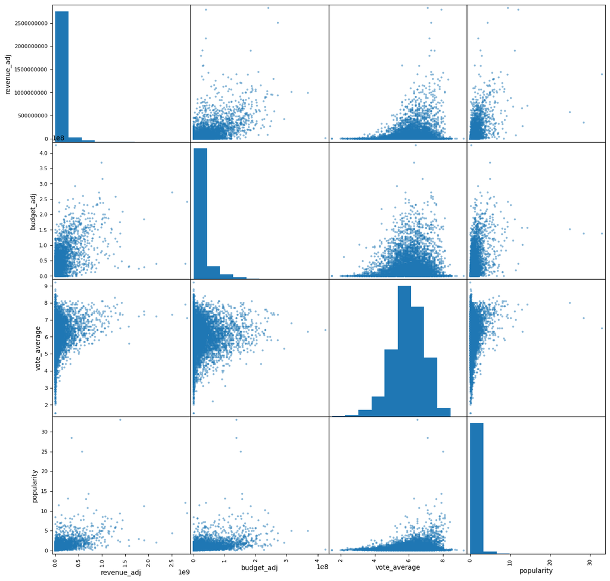

```python
pd.plotting.scatter_matrix(df[['revenue_adj', 'budget_adj', 'vote_average', 'popularity']], figsize=(15,15));
```

**Findings:**

From the plot above we find out:

- Budget is the most factor affecting revenue.
- Popularity has some influence, but it isn't as strong as budget.
- Vote average has little effect on revenue.

### 1.1 The relation between revenue and budget:

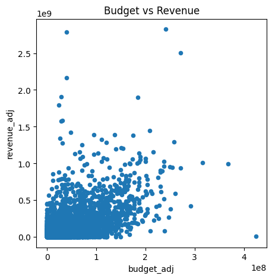

```python
df.plot(x='budget_adj',y='revenue_adj',kind='scatter', title='Budget vs Revenue',figsize=(5,5));
```

We see a positive correlation, but the data is dense when the `budget_adj` is less than 1e8.

Lets fix it to see the relation better:

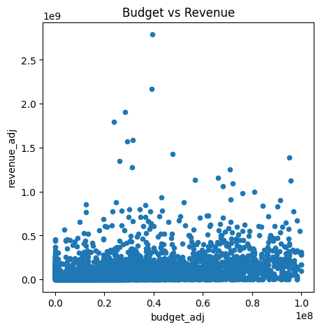

```python
# filter the dataframe to select only movies with budget less than 100M$
df[df['budget_adj'] <= 100000000].plot(x='budget_adj',y='revenue_adj',kind='scatter', title='Budget vs Revenue',figsize=(5,5));
```

**Findings:**

- Higher budgets tend to lead to higher revenues, but not always.
- Some low-budget movies can still make high revenue.
- Increasing the budget does not always guarantee a proportional increase in revenue.

### 1.1.1 Find the movie with the highest revenue and its corresponding budget:

```python
#  find max revenue in the dataset
max_revenue = df['revenue_adj'].max()
# find movie with max revenue
max_revenue_movie = df[df['revenue_adj'] == max_revenue]

print("Movie with Highest Revenue:")
max_revenue_movie[['original_title', 'revenue_adj', 'budget_adj']]
```

```
Movie with Highest Revenue:
```

|  | original_title | revenue_adj | budget_adj |
| --- | --- | --- | --- |
| 1386 | Avatar | 2.827124e+09 | 2.408869e+08 |

Avatar movie had the highest revenue, and it had a high budget, but not the highest one.

### 1.1.2 Find the movie with the highest budget and its corresponding revenue:

```python
#  find max budget in the dataset
max_budget = df['budget_adj'].max()
# find movie with max budget
max_budget_movie = df[df['budget_adj'] == max_budget]

print("Movie with Highest Budget:")
max_budget_movie[['original_title', 'budget_adj', 'revenue_adj']]
```

```
Movie with Highest Budget:
```

|  | original_title | budget_adj | revenue_adj |
| --- | --- | --- | --- |
| 2244 | The Warrior's Way | 425000000.0 | 11087569.0 |

The Warrior’s movie had the highest budget, but it had an extremely low revenue compared to its cost, meaning it was a huge financial failure.

### 1.2 The relation between revenue and vote avarage:

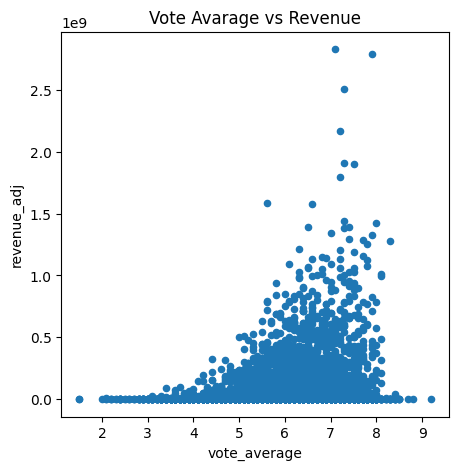

```python
df.plot(x='vote_average',y='revenue_adj',kind='scatter', title='Vote Avarage vs Revenue',figsize=(5,5));
```

```python
df[['vote_average', 'revenue_adj']].corr()
```

|  | vote_average | revenue_adj |
| --- | --- | --- |
| vote_average | 1.00000 | 0.19968 |
| revenue_adj | 0.19968 | 1.00000 |

From the above figure and correlation, a high rating alone does not guarantee high revenue.

### 1.3 The relation between revenue and popularity:

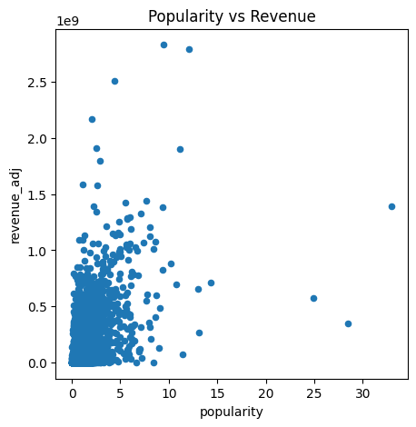

```python
df.plot(x='popularity',y='revenue_adj',kind='scatter', title='Popularity vs Revenue',figsize=(5,5));
```

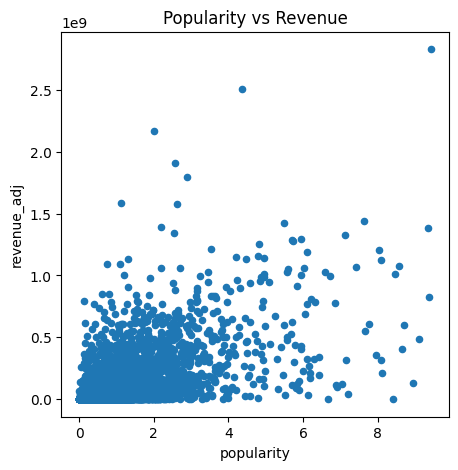

```python
df[df['popularity'] <= 10].plot(x='popularity',y='revenue_adj',kind='scatter', title='Popularity vs Revenue',figsize=(5,5));
```

```python
df[['popularity', 'revenue_adj']].corr()
```

|  | popularity | revenue_adj |
| --- | --- | --- |
| popularity | 1.00000 | 0.60837 |
| revenue_adj | 0.60837 | 1.00000 |

There's a positive relation between popularity and revenue, but it's only moderately strong. High popularity does not guarantee extremely high revenue, and some movies with moderate popularity can still achieve high revenue.

### 1.4 The count of successful and failed Movies

In this part, we'll consider a movie successful if its profit (revenue - budget) is higher than the median profit of all movies.

```python
# calculate the profit of each movie in the dataset
df['profit'] = df['revenue_adj'] - df['budget_adj']

# new new column 'success'
# if profit is higher than the median profit (true) - else(false)
df['success'] = df['profit'] > df['profit'].median()
df['success'].value_counts()
```

```
False    6956
True     3770
Name: success, dtype: int64
```

### 2. How are movies distributed by genre?

- First, create a function to split genres and count them in the dataframe:

```python
# calc each genre in the df
def genre_counts(df, column='genres'):
    return (
        df[column].str.split('|').explode().value_counts()
    )
```

- **Function explanation:**
  - Its used to caclulate the count of each genre in the dataframe.
  - `.str.split('|')` as the genres are seperated with `|`, we split these strings into a list based on the `|`.
  - `.explode()` this is used to divide the list of each row into multiple rows each genre in a row.
  - `.value_counts()` then this to cuont each genre appearance so we can use it in analyzing later.

### 2.1 Which genres are most popular from year to year?

Now we will count the number of movies in each genre per year in order to analyze the trends over the years.

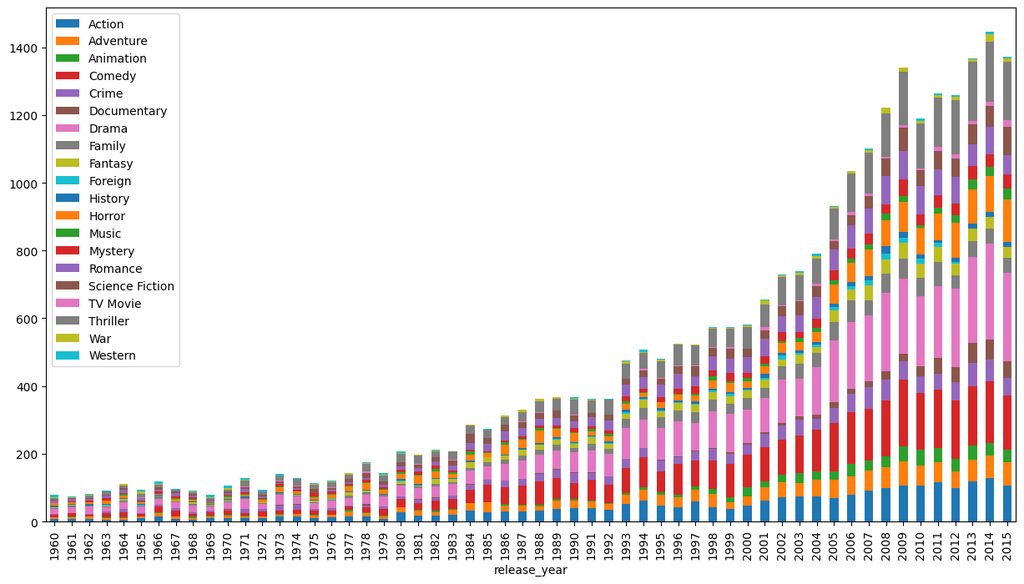

```python
# group the df by the date movie released
# then apply the function to count each genre
# unstack to convert into wide format df for better visualization
# then sort the data ascending by release_year
genre_df = df.groupby('release_year').apply(genre_counts).unstack().sort_index()

# use stacked bar plot to visualize the data
genre_df.plot(kind='bar', stacked=True, figsize=(15, 8));
```

As we seen in the stacked bar plot above we relaese some findings:

- The total number of released movies has increased noticably after 2000s.
- Movie genres like `Drama` and `comedy` were the most 2 genres that increased over the years.
- Genres like `war` and `westren` has the least appearance in the last years, otherwise `animation` movies start to show up more in the last years.

### 2.2 Which movie genre is the most popular acroos all years in the dataset?

Here we will see the distribution of movie genres over the years so we can know which one is the most popular one in the range of years **(1960 - 2015)**.

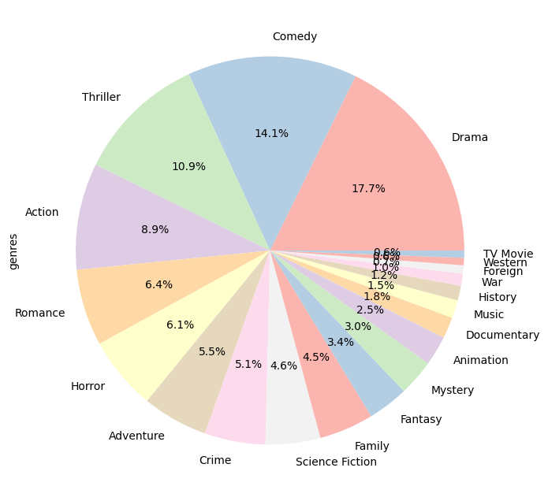

```python
# count of each genre
genre_df = genre_counts(df)

# color mapping to Pastel1
clr = plt.cm.Pastel1.colors

# use pie chart to visualize the data
genre_df.plot.pie(figsize=(8,8), autopct='%1.1f%%', colors=clr);

# # print genres in descending order
# sorted_genres = genre_df.sort_values(ascending=False)
# print(sorted_genres.index.tolist())
```

As we see in the pie chart `Drama`, `Comedy`, and `Thriller` were the top 3 most popular genres from 1960 to 2015, each making up more than 10% of the total. While `Foreign`, `Western`, and `TV Movie` were the least popular ones with each contributing less than 1% of the total.

### 2.3 Which movie genre is the most popular in the most occurring year in the dataset?

- First, we need to find out the most frequent year in the dataset:

```python
# Find out the most frequent year in the dataset
most_common_year = df['release_year'].mode()[0]
print('The most frequent year in the dataset:',most_common_year)

# Filter according to the year
df_year = df[df['release_year'] == most_common_year]
```

```
The most frequent year in the dataset: 2014
```

- To confirm, let's create a bar chart that shows the number of movies released each year:

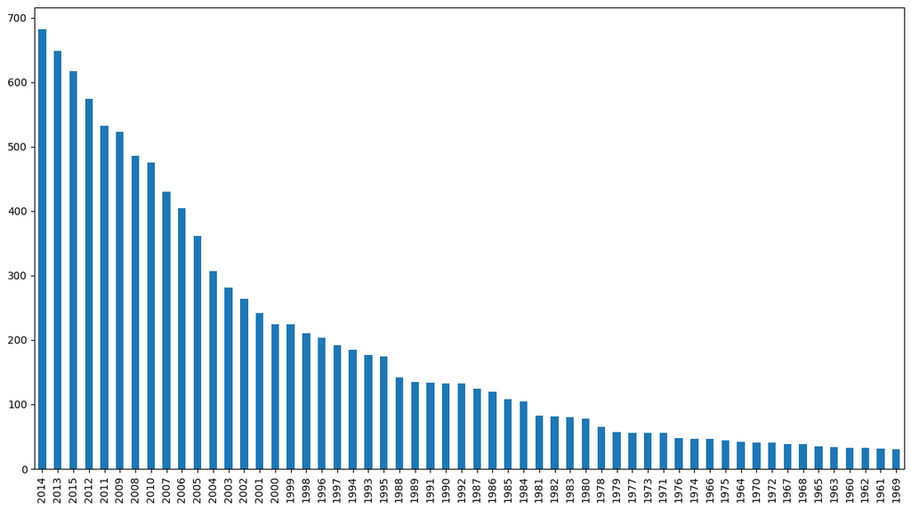

```python
df['release_year'].value_counts().plot.bar(figsize=(15,8));
```

We find out the most common year in the dataset is **2014**, so we'll use it to see which movie genre was the most popular back then.

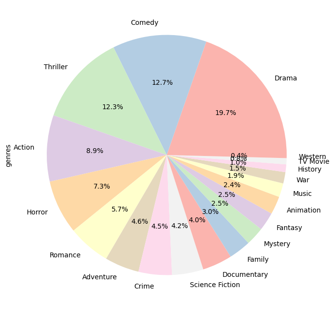

```python
# count of each genre
genre_df_14 = genre_counts(df_year)

# color mapping to Pastel1
clr = plt.cm.Pastel1.colors

# use pie chart to visualize the data
genre_df_14.plot.pie(figsize=(8,8), autopct='%1.1f%%', colors=clr);
```

From the pie chart, `Drama` `Comedy`, and `Thriller` were the most popular genres in 2014, each making up more than 12% of the total. While `Western`, and `TV Movie` were the least popular ones with each contributing less than 1% of the total.

But we also noticed that `Foreign` doesn't appear in the chart, meaning that in this dataset in the year 2014, there is no movie with `Foreign` genre.

Let's make sure by finding out the sum of `Foreign` genres in 2014:

```python
# count the occurrences Foreign in genres column in 2014 dataset
df_year['genres'].str.contains('Foreign', na=False).sum()
```

```
0
```

As appears above, the sum is **0**, meaning that there wasn't a `Foreign` movie in that year.

## Conclusions

In this analysis, we explored factors influencing movie revenue, budget, popularity, and genre trends. The main questions we investigated were:

1. **What variables lead to higher movie revenue?**
   - Budget is the strongest factor affecting revenue (correlation: 0.65), followed by popularity (0.61), Ratings (0.2) have little impact.
   - Only 35% of movies were classified as successful based on profit (revenue - budget).
   - Higher budget tend to lead to higher revenue, but not always, as some low budget movies still generate great revenue.
   - Avatar had the highest revenue, while The Warrior’s Way had the highest budget but failed financially.
2. **How are movies distributed by genre?**
   - Movie releases increased significantly after 2000, with Drama and Comedy being the most popular, while Western and War movies became less common.
   - From 1960 to 2015, Drama, Comedy, and Thriller were the most popular genres (each >10%). while Foreign, Western, and TV Movies were the least popular genres (each <1%).
   - 2014 was the most frequent year in the dataset, with Drama, Comedy, and Thriller as the most popular genres, each making up >12% of all movies that year.
   - No Foreign movies were recorded in 2014.

**But there were limitations, such as:**

- The dataset may have missing or wrong values (zero-budget/revenue) in revenue and budget, which could affect the findings.
- While we study the relation between certain variables and revenue, but we can't make sure that these factors guarantee higher revenue.
- Future analysis could explore marketing impact to better predict movie success.

```python
# Running this cell will execute a bash command to convert this notebook to an .html file
!python -m nbconvert --to html Investigate_a_Dataset.ipynb
```

```
[NbConvertApp] Converting notebook Investigate_a_Dataset.ipynb to html
[NbConvertApp] WARNING | Alternative text is missing on 10 image(s).
[NbConvertApp] Writing 1282687 bytes to Investigate_a_Dataset.html
```